# The Evolution of Movie Trends

## Overview

This project is aimed at analyzing the relationship between movie genres, audience preferences, and streaming platforms' choices. By analyzing random movies data from IMDB, Amazon, Disney+, and Netflix, we aim to understand how movies trends have evolved over time.

In the following part of the project, we deal with the chosen datasets with data manipulation and visualization tools. We will further analyze the data with the application of machine learning techniques in the following months, in order to find the evolution of movie trends in the industry.

## Motivation

Movies are one of the essentials in our daily life, and watching movies is a very popular form of entertainment and relaxation. Since 28 December 1895, when the Lumiere brothers' had held the first commercial, public screening of ten short films in Paris (Wikipedia, History of film), the film industry has achieved significant growth worldwide. Over the past 130 years, with the vigorous development of technology, the way people watched movies has also been constantly changing, which in turn has influenced the production, distribution and consumption of films. As a result, various genres of movies have emerged throughout the history, and the entire industry has flourished.

In recent decades, the film industry has undergone another major transformation (Wikipedia, History of Film): a rapid shift toward streaming platforms such as Amazon, Netflix, and Disney+. These streaming platforms, together with the cinemas, now represent two dominant modes of film distribution, which also bring new challenges and opportunities for the future development of the film industry.  
Given the rapid shifts, we were motivated to explore how people's preferences, production factors, and streaming platforms' choices jointly shape and transform the movie industry. Our goal is to apply our data science skills and concepts to deal with the following three real-world questions:  
**1. What are the differences in people's preferences for different genres of movies over time?**  
By answering this question, we aim to identify the most popular movie genres in every five-year period, analyze how these trends have evolved over time, and examine how global events have influenced audience preferences. We hope that this model can be used to predict the genres of movies that will be popular in the future.  
**2. What are the main factors that influence the box office?**  
What factors truly determine a film’s commercial success? Is it the director, the main cast, audience ratings and reputation, film duration, or genre? To what extent does each of these factors contribute to box office performance? By exploring this question, we aim to develop a model capable of predicting the likelihood of a film achieving high box office revenue.  
**3. Do streaming platforms have specific preferences in the genres of movies they release?**  
By comparing the proportion of various genres of movies shown on each platform, we hope to help movies choose the streaming platform for their release, thereby increasing the likelihood of achieving success online.  
**In general, by dealing with these three questions, we aim to understand how the development of technology and the production process of movies has influenced audience preferences and economic outcomes in the movie industry worldwide, and set up a model which helps make future films more likely to be successful.**

## Data Source

**1. IMDB Movies Dataset**  
This dataset contains 10178 random movies obtained from IMDB website. Columns include: movie name, release date, user rating, genre of the movie, an overview of the movie, crew members, original title of the movie, release status, originally released language, movie budget, revenue generated worldwide, and release country.  
We will mainly use the following columns: movie name, release date, user rating, genre of the movie, crew members, movie budget, and revenue.  
URL: https://www.kaggle.com/datasets/ashpalsingh1525/imdb-movies-dataset

**2. Amazon Prime Movies and TV Shows**  
The dataset contains 9668 random movies and tv shows listing on Amazon Prime Video. Columns include: unique show id, type of the video, title of movie or show, director, cast, country of production, data added on Prime, release year, rating, duration, genre, and description of the movie or show.  
We will mainly use the following columns: movie name, director, cast, duration, genre.  
URL: https://www.kaggle.com/datasets/shivamb/amazon-prime-movies-and-tv-shows

**3. Disney+ Movies and TV Shows**  
The dataset contains 1450 random movies and tv shows listing on Disney+. Columns include: unique show id, type of the video, title of movie or show, director, cast, country of production, data added on Prime, release year, rating, duration, genre, and description of the movie or show.  
We will mainly use the following columns: movie name, director, cast, duration, genre.  
URL: https://www.kaggle.com/datasets/shivamb/disney-movies-and-tv-shows

**4. Netflix Movies and TV Shows**  
The dataset contains 8807 random movies and tv shows listing on Netflix. Columns include: unique show id, type of the video, title of movie or show, director, cast, country of production, data added on Prime, release year, rating, duration, genre, and description of the movie or show.  
We will mainly use the following columns: movie name, director, cast, duration, genre.  
URL: https://www.kaggle.com/datasets/shivamb/netflix-shows

**We use IMDB dataset as our main dataset, and the three other datasets can be merged on our main dataset through movie name, in order to investigate the preferences of the streaming platforms. At the same time, these three datasets can also provide additional information such as the duration of the movies and the directors.**

## Data Description

We are interested in the following variables in the IMDB dataset: names, date_x (release date of the movie), score (user rating), genre, crew (crew members of the movie, but excluding the director), budget_x (movie budget), and revenue. We might also analyze the description of the movies. The shape of this dataset is (10178, 12). In other words, this dataset includes 10178 unique rows, and 12 different features. There are some missing values in the columns: genre, crew. We will choose to remove these row in the missing values if necessary in the future.  
In the Amazon, Disney+, Netflix datasets, we are interested in the following variables: title, director, cast, data_added (data added on the streaming platforms), duration (duration of the movie or show), listed_in (genre). Probably we will also analyze the description of the movies. The shapes of these datasets are (9,668, 12), (1,450, 12), and (8,807, 12), respectively. As with the previous dataset, the first number indicates the number of rows (observations), and the second number indicates the number of features (columns). There are some missing values in the column: director, cast, data_added, and duration. We will choose to remove these rows in the missing values if necessary in the future.  
We will merge these three datasets to our main dateset on movie titles, and drop the columns that are definitely not needed.

## Data Manipulation

In the first step, we imported the necessary libraries and datasets.

```python
import pandas as pd
import matplotlib.pyplot as plt
import seaborn as sns
```

```python
# import datasets
imdb = pd.read_csv("data/imdb_movies.csv")
amazon = pd.read_csv("data/amazon_prime_titles.csv")
disney = pd.read_csv("data/disney_plus_titles.csv")
netflix = pd.read_csv("data/netflix_titles.csv")
```

The following outputs display the first three rows of each dataset, and the detailed descriptions of the datasets are provided above in the data source and data description part.

```python
imdb.head(3)
```

|  | names | date_x | score | genre | overview | crew | orig_title | status | orig_lang | budget_x | revenue | country |
| --- | --- | --- | --- | --- | --- | --- | --- | --- | --- | --- | --- | --- |
| 0 | Creed III | 03/02/2023 | 73.0 | Drama, Action | After dominating the boxing world, Adonis Cree... | Michael B. Jordan, Adonis Creed, Tessa Thompso... | Creed III | Released | English | 75000000.0 | 2.716167e+08 | AU |
| 1 | Avatar: The Way of Water | 12/15/2022 | 78.0 | Science Fiction, Adventure, Action | Set more than a decade after the events of the... | Sam Worthington, Jake Sully, Zoe Saldaña, Neyt... | Avatar: The Way of Water | Released | English | 460000000.0 | 2.316795e+09 | AU |
| 2 | The Super Mario Bros. Movie | 04/05/2023 | 76.0 | Animation, Adventure, Family, Fantasy, Comedy | While working underground to fix a water main,... | Chris Pratt, Mario (voice), Anya Taylor-Joy, P... | The Super Mario Bros. Movie | Released | English | 100000000.0 | 7.244590e+08 | AU |

```python
amazon.head(3)
```

|  | show_id | type | title | director | cast | country | date_added | release_year | rating | duration | listed_in | description |
| --- | --- | --- | --- | --- | --- | --- | --- | --- | --- | --- | --- | --- |
| 0 | s1 | Movie | The Grand Seduction | Don McKellar | Brendan Gleeson, Taylor Kitsch, Gordon Pinsent | Canada | March 30, 2021 | 2014 | NaN | 113 min | Comedy, Drama | A small fishing village must procure a local d... |
| 1 | s2 | Movie | Take Care Good Night | Girish Joshi | Mahesh Manjrekar, Abhay Mahajan, Sachin Khedekar | India | March 30, 2021 | 2018 | 13+ | 110 min | Drama, International | A Metro Family decides to fight a Cyber Crimin... |
| 2 | s3 | Movie | Secrets of Deception | Josh Webber | Tom Sizemore, Lorenzo Lamas, Robert LaSardo, R... | United States | March 30, 2021 | 2017 | NaN | 74 min | Action, Drama, Suspense | After a man discovers his wife is cheating on ... |

```python
disney.head(3)
```

|  | show_id | type | title | director | cast | country | date_added | release_year | rating | duration | listed_in | description |
| --- | --- | --- | --- | --- | --- | --- | --- | --- | --- | --- | --- | --- |
| 0 | s1 | Movie | Duck the Halls: A Mickey Mouse Christmas Special | Alonso Ramirez Ramos, Dave Wasson | Chris Diamantopoulos, Tony Anselmo, Tress MacN... | NaN | November 26, 2021 | 2016 | TV-G | 23 min | Animation, Family | Join Mickey and the gang as they duck the halls! |
| 1 | s2 | Movie | Ernest Saves Christmas | John Cherry | Jim Varney, Noelle Parker, Douglas Seale | NaN | November 26, 2021 | 1988 | PG | 91 min | Comedy | Santa Claus passes his magic bag to a new St. ... |
| 2 | s3 | Movie | Ice Age: A Mammoth Christmas | Karen Disher | Raymond Albert Romano, John Leguizamo, Denis L... | United States | November 26, 2021 | 2011 | TV-G | 23 min | Animation, Comedy, Family | Sid the Sloth is on Santa's naughty list. |

```python
netflix.head(3)
```

|  | show_id | type | title | director | cast | country | date_added | release_year | rating | duration | listed_in | description |
| --- | --- | --- | --- | --- | --- | --- | --- | --- | --- | --- | --- | --- |
| 0 | s1 | Movie | Dick Johnson Is Dead | Kirsten Johnson | NaN | United States | September 25, 2021 | 2020 | PG-13 | 90 min | Documentaries | As her father nears the end of his life, filmm... |
| 1 | s2 | TV Show | Blood & Water | NaN | Ama Qamata, Khosi Ngema, Gail Mabalane, Thaban... | South Africa | September 24, 2021 | 2021 | TV-MA | 2 Seasons | International TV Shows, TV Dramas, TV Mysteries | After crossing paths at a party, a Cape Town t... |
| 2 | s3 | TV Show | Ganglands | Julien Leclercq | Sami Bouajila, Tracy Gotoas, Samuel Jouy, Nabi... | NaN | September 24, 2021 | 2021 | TV-MA | 1 Season | Crime TV Shows, International TV Shows, TV Act... | To protect his family from a powerful drug lor... |

```python
print(imdb.shape)
print(amazon.shape)
print(disney.shape)
print(netflix.shape)
```

```
(10178, 12)
(9668, 12)
(1450, 12)
(8807, 12)
```

We added a new column named 'app' to indicate the platform on which each movie is listed. In addition, we excluded TV shows from the dataset, as our analysis focuses only on movies. Finally, we merged the Netflix, Amazon, and Disney datasets with the IMDB dataset based on movie titles.

```python
amazon['app'] = 'Amazon'
disney['app'] = 'Disney'
netflix['app'] = 'Netflix'
apps = pd.concat([amazon,disney,netflix],axis='rows',ignore_index=True)
apps = apps[apps['type'] == 'Movie']
df = imdb.merge(apps, left_on='names', right_on='title', how='left')
```

After merging, we dropped unnecessary or duplicate columns and renamed several columns for easier readability. Then, we filled the missing values in the rating column with “Not Rated”. We also converted the duration field from a string containing “min” into an integer representing the number of minutes. Since the crew column included many crew members and character names, we decided to extract only the main two crew members and list them in a new column. Finally, we converted the date column into a datetime format, created a year column showing the release year of each film, and generated a year group column that categorizes films into ranges such as 2001–2005.

```python
df.drop(columns=['country_y','release_year','status','type','title'], inplace=True)
df.rename(columns={'names':'titles','country_x':'country', 'date_x': 'date',
                    'budget_x': 'budget', 'duration':'duration(min)'}, inplace=True)

# fill missing value for rating column
df['rating'] = df['rating'].fillna('Not Rated')

# clean duration column
df['duration(min)'] = df['duration(min)'].str.replace(' min','').astype('Int64')

# find out the main cast
df['main_cast_1'] = df['crew'].str.split(',').str[0]
df['main_cast_2'] = df['crew'].str.split(',').str[2]

# divide data into 5-year groups
df['date'] = pd.to_datetime(df['date'])
df['year'] = df['date'].dt.year
df['year_group'] = ((df['year'] - 1) // 5) * 5  + 1
# create labels like "2001-2005", "2006-2010", etc.
df['year_group_label'] = df['year_group'].astype(str) + '-' + (df['year_group'] + 4).astype(str)
```

In this step, we transformed the genre column to facilitate quantitative analysis of categorical movie attributes. Since each movie could belong to multiple genres, we extracted all unique genre labels and created dummy variables for each genre, assigning a value of 1 if the movie belonged to that genre and 0 otherwise.

```python
# create genres dummy variables
# Split genres and combine into one list without duplicates
all_genres = df['genre'].dropna().str.split(',').explode().str.strip().unique()
genre_df = df[['titles','genre']].copy()
for genre in all_genres:
    genre_df.loc[genre_df["genre"].str.contains(genre, na=False), genre] = 1
    genre_df[genre] = genre_df[genre].fillna(0)
df = df.merge(genre_df, on=['titles','genre'], how='left')
```

The following output displays the shape and the first five rows of the final dataset.

We can see that the final dataset contains 11,285 rows and 44 columns. The number of rows in the final dataset is greater than that in the IMDb dataset because some movies appear on more than one streaming platform.

```python
print(df.shape)

df.head(5)
```

```
(11285, 44)
```

|  | titles | date | score | genre | overview | crew | orig_title | orig_lang | budget | revenue | ... | Crime | Horror | Mystery | History | War | Documentary | Romance | Music | Western | TV Movie |
| --- | --- | --- | --- | --- | --- | --- | --- | --- | --- | --- | --- | --- | --- | --- | --- | --- | --- | --- | --- | --- | --- |
| 0 | Creed III | 2023-03-02 | 73.0 | Drama, Action | After dominating the boxing world, Adonis Cree... | Michael B. Jordan, Adonis Creed, Tessa Thompso... | Creed III | English | 75000000.0 | 2.716167e+08 | ... | 0.0 | 0.0 | 0.0 | 0.0 | 0.0 | 0.0 | 0.0 | 0.0 | 0.0 | 0.0 |
| 1 | Avatar: The Way of Water | 2022-12-15 | 78.0 | Science Fiction, Adventure, Action | Set more than a decade after the events of the... | Sam Worthington, Jake Sully, Zoe Saldaña, Neyt... | Avatar: The Way of Water | English | 460000000.0 | 2.316795e+09 | ... | 0.0 | 0.0 | 0.0 | 0.0 | 0.0 | 0.0 | 0.0 | 0.0 | 0.0 | 0.0 |
| 2 | The Super Mario Bros. Movie | 2023-04-05 | 76.0 | Animation, Adventure, Family, Fantasy, Comedy | While working underground to fix a water main,... | Chris Pratt, Mario (voice), Anya Taylor-Joy, P... | The Super Mario Bros. Movie | English | 100000000.0 | 7.244590e+08 | ... | 0.0 | 0.0 | 0.0 | 0.0 | 0.0 | 0.0 | 0.0 | 0.0 | 0.0 | 0.0 |
| 3 | Mummies | 2023-01-05 | 70.0 | Animation, Comedy, Family, Adventure, Fantasy | Through a series of unfortunate events, three ... | Óscar Barberán, Thut (voice), Ana Esther Albor... | Momias | Spanish, Castilian | 12300000.0 | 3.420000e+07 | ... | 0.0 | 0.0 | 0.0 | 0.0 | 0.0 | 0.0 | 0.0 | 0.0 | 0.0 | 0.0 |
| 4 | Supercell | 2023-03-17 | 61.0 | Action | Good-hearted teenager William always lived in ... | Skeet Ulrich, Roy Cameron, Anne Heche, Dr Quin... | Supercell | English | 77000000.0 | 3.409420e+08 | ... | 0.0 | 0.0 | 0.0 | 0.0 | 0.0 | 0.0 | 0.0 | 0.0 | 0.0 | 0.0 |

5 rows × 44 columns

## Data Visualization

At the beginning of the visualization, we want to gain an overall understanding of the characteristics of the movies, such as how many movies are in each year group and how much a movie typically earns.

#### Number of Movies by Year Group

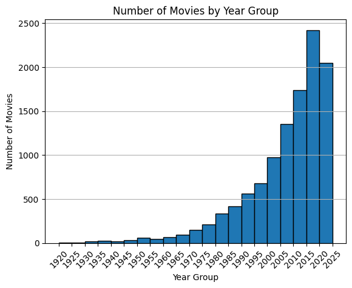

```python
plt.hist(df['year_group'],bins=range(1920,2026,5), edgecolor='black')
plt.xlabel('Year Group')
plt.ylabel('Number of Movies')
plt.title('Number of Movies by Year Group')
plt.xticks(range(1920,2026,5), rotation=45)
plt.grid(axis='y')
plt.show()
```

We observe that only a small number of movies are included in the dataset during the early decades (1920–1960). After 1965, however, the number of movies begins to steadily increase. This growth accelerates in the 2000s and reaches its peak between 2015 and 2020, with around 2,500 movies. After 2020, the number of movies declines.

#### Numbers of Movies by Revenue

Then, We want to check the number of movies by Revenue.

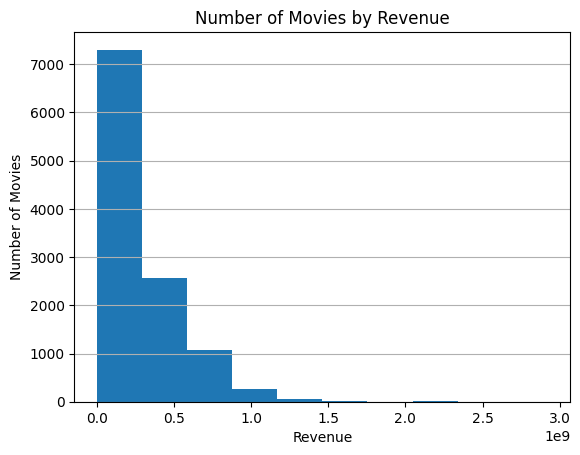

```python
plt.hist(df['revenue'])
plt.xlabel('Revenue')
plt.ylabel('Number of Movies')
plt.title('Number of Movies by Revenue')
plt.grid(axis='y')
plt.show()
```

In this graph, the right tail of the distribution is too long, and since most movies have revenues below $1 billion, it is difficult to observe the exact pattern. Therefore, we will create another graph to show the distribution of movies with revenues under $1 billion.

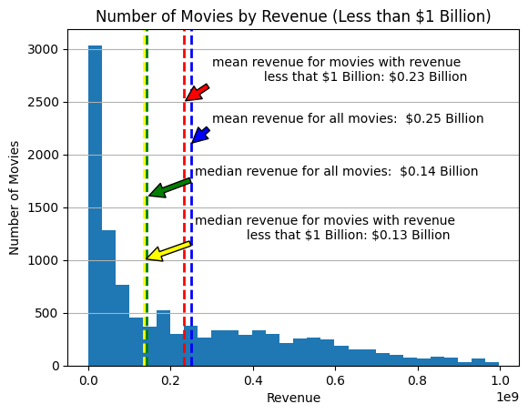

```python
plt.hist(df[df['revenue']<1e9]['revenue'], bins=30)
# Add mean line
mean_revenue_1e9 = df[df['revenue']<1e9]['revenue'].mean()
plt.axvline(mean_revenue_1e9, color='red', linestyle='--', linewidth=2)
plt.annotate(f'mean revenue for movies with revenue\n \
            less that \\$1 Billion: \\${(mean_revenue_1e9/1e9):.2f} Billion',
            xy=(mean_revenue_1e9, 2500), xytext=(3e8,2700),
            arrowprops=dict(facecolor='red', shrink=0.05))

mean_revenue = df['revenue'].mean()
plt.axvline(mean_revenue, color='blue', linestyle='--', linewidth=2)
plt.annotate(f'mean revenue for all movies:  ${mean_revenue/1e9:.2f} Billion',
            xy=(mean_revenue, 2100), xytext=(3e8,2300),
            arrowprops=dict(facecolor='blue', shrink=0.05))

median_revenue = df['revenue'].median()
plt.axvline(median_revenue, color='green', linestyle='--', linewidth=2)
plt.annotate(f'median revenue for all movies:  ${median_revenue/1e9:.2f} Billion',
            xy=(median_revenue, 1600), xytext=(2.6e8,1800),
            arrowprops=dict(facecolor='green', shrink=0.05))

median_revenue_1e9 = df[df['revenue']<1e9]['revenue'].median()
plt.axvline(median_revenue_1e9, color='yellow', linestyle='--', linewidth=2)
plt.annotate(f'median revenue for movies with revenue\n \
            less that \\$1 Billion: \\${(median_revenue_1e9/1e9):.2f} Billion',
            xy=(median_revenue_1e9, 1000), xytext=(2.6e8,1200),
            arrowprops=dict(facecolor='yellow', shrink=0.05))

plt.xlabel('Revenue')
plt.ylabel('Number of Movies')
plt.title('Number of Movies by Revenue (Less than $1 Billion)')
plt.grid(axis='y')
plt.show()
```

This histogram shows the distribution of movie revenues for films earning less than $1 billion. The graph reveals that the majority of movies still cluster at the lower end of the revenue scale (0-0.1 Billion), with a sharp decline as revenue increases.

The vertical lines highlight key summary statistics: the mean revenue for all movies is approximately $0.25 billion, while the mean for movies earning less than $1 billion is slightly lower at $0.23 billion. The median revenue for all movies is $0.14 billion, indicating that half of the movies earn below this value. For movies under $1 billion, the median is $0.13 billion, which is very close to the overall median. These results reveal the right-skewed distribution of movie revenues, where a small number of films raise the mean, while the majority of movies earn substantially less.

#### Budget vs Revenue

Since our goal is to explore the factors that influence revenue, we want to include additional plots. However, revenue naturally tends to increase over time due to inflation, which can distort the analysis. To account for this effect, we created a plot showing the relationship between budget and revenue, as budgets also tend to rise over the years.

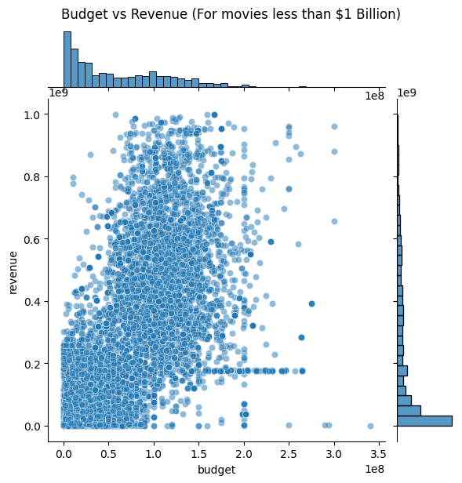

```python
g = sns.jointplot(x='budget', y='revenue', data=df[df['revenue']<1e9], alpha=.5)
g.figure.suptitle("Budget vs Revenue (For movies less than $1 Billion)", y=1.02)
plt.show()
```

This scatterplot shows the relationship between budget and revenue for movies earning less than $1 billion. Each point represents a movie, with its budget on the x-axis and revenue on the y-axis. The marginal histograms on the top and right sides illustrate the distributions of budgets and revenues.

From the graph, we can see that most movies cluster within the budget range of $0–150 million and revenue range of $0–400 million, indicating that the majority of films have moderate production costs and earnings. There is also a positive trend: movies with higher budgets generally tend to earn more revenue. However, the scatter also reveals considerable variation. In other words, further analysis in the future will be necessary.

#### Distribution of Genres for Movies across different Streaming Apps

Since we also want to explore the preferences of streaming platforms, such as which genres they favor, we created a stacked bar chart that shows the number of movies in each genre across the different streaming apps.

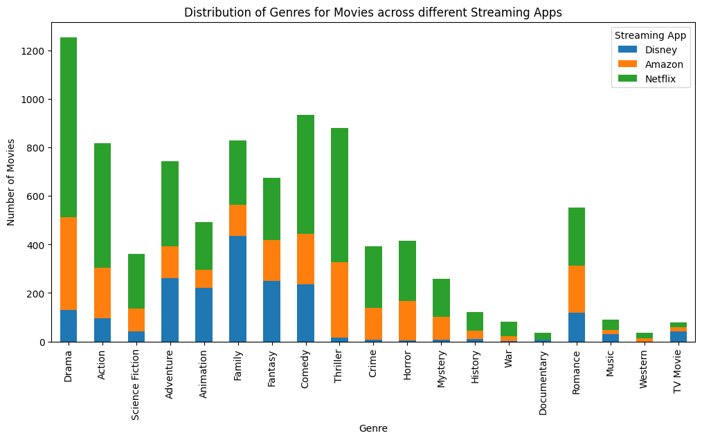

```python
count_disney = df[df['app'] == 'Disney'][all_genres].sum()
count_amazon = df[df['app'] == 'Amazon'][all_genres].sum()
count_netflix = df[df['app'] == 'Netflix'][all_genres].sum()

# Create DataFrame
counts_df = pd.DataFrame({
    'Disney': count_disney,
    'Amazon': count_amazon,
    'Netflix': count_netflix
})

counts_df.plot(kind='bar', stacked = True, figsize=(12,6))
plt.title("Distribution of Genres for Movies across different Streaming Apps")
plt.xlabel('Genre')
plt.ylabel('Number of Movies')
plt.legend(title='Streaming App')
plt.show()
```

A clear pattern emerges in the genre preferences of each app. For example, Disney strongly favors family movies and has very few movies in thriller, crime, war, or horror. In contrast, Netflix features a large number of thriller and drama films. Amazon displays a similar pattern to Netflix but with fewer movies in each category.

## References

Wikipedia Contributors. “History of Film.” *Wikipedia*, Wikimedia Foundation, 14 Dec. 2018, en.wikipedia.org/wiki/History_of_film.